# Final Project Analysis

Young Jang

2025-05-06

# Introduction

The cost of international education is a significant consideration for students worldwide. Understanding the factors that drive tuition fees is crucial for prospective students, educational institutions, and policymakers. This project aims to analyze a dataset containing information about international education costs across various institutions and programs. By employing linear regression modeling, we seek to identify and quantify the impact of several key numeric and categorical factors, specifically Living Cost Index, Insurance USD, Rent USD, Level of study, and Program Duration, on the tuition fees (in USD). The findings will provide insights into the economic determinants of international education costs.

# Methods

We utilize multiple linear regression to model the relationship between the continuous target variable, Tuition_USD, and several predictor variables. The basic form of the model is:

Y=B0+B1X1 +B2X2+⋯+BpXp+e

Where Y represents Tuition_USD (after a log transformation to address initial assumption violations), Xirepresent the predictor variables (Living_Cost_Index, Insurance_USD, Rent_USD, Level (treated as a factor), and Duration_Years), Bi are the coefficients quantifying the relationship between each predictor and the target, and e is the error term.

We initially checked the key assumptions of linear regression: linearity, independence of errors, homoscedasticity, normality of errors, and low multicollinearity using visual diagnostics (residual plots, Q-Q plots) and statistical tests (Durbin-Watson, Breusch-Pagan, Shapiro-Wilk, VIF).

Due to initial violations of linearity and heteroscedasticity, we applied a natural logarithm transformation to the Tuition_USD variable. To address the remaining heteroscedasticity, we employed robust standard errors for the coefficient estimates and hypothesis testing using the sandwich and lmtest packages in R. These robust standard errors provide more reliable inference even when the assumption of constant variance of errors is violated.

The coefficients in the log-transformed model are interpreted as the approximate percentage change in Tuition_USD for a one-unit change in the predictor variable (for numeric predictors) or the percentage difference relative to the baseline category (for the factor Level). Hypothesis tests (t-tests) are used to determine the statistical significance of each predictor’s coefficient.

## Data Description

The dataset contains 907 observations with information on international education costs. The key variables for our analysis are:

Tuition_USD (Continuous - Target): The tuition fees for the program in US dollars. This variable was log-transformed for the modeling process. Living_Cost_Index (Numeric): An index representing the relative cost of living in the city. Insurance_USD (Numeric): The annual cost of health insurance in US dollars. Rent_USD (Numeric): The average monthly rent in US dollars in the city. Level (Categorical): The level of study (Bachelor, Master, PhD). This was treated as a factor in the model, with Bachelor serving as the baseline category. Duration_Years (Numeric): The typical duration of the program in years. After filtering out rows where Tuition_USD was zero (as the logarithm of zero is undefined), the analysis was conducted on a reduced dataset. The initial exploration of the data and the subsequent regression modeling focused on understanding how these specific factors relate to the cost of international education tuition.

## Develope Hypothesis

Hypothesis 1 (Living Cost Index): Null Hypothesis (H0): There is no significant linear relationship between the Living Cost Index and Tuition_USD (after log transformation) Alternative Hypothesis (H1): There is a significant linear relationship between the Living Cost Index and Tuition_USD (after log transformation)

Hypothesis 2 (Insurance USD): Null Hypothesis (H0): There is no significant linear relationship between the cost of Insurance and Tuition_USD (after log transformation) Alternative Hypothesis (H1): There is a significant linear relationship between the cost of Insurance and Tuition_USD (after log transformation)

Hypothesis 3 (Rent USD): Null Hypothesis (H0): There is no significant linear relationship between the average monthly Rent and Tuition_USD (after log transformation) Alternative Hypothesis (H1): There is a significant linear relationship between the average monthly Rent and Tuition_USD (after log transformation)

Hypothesis 4 (Duration Years): Null Hypothesis (H0): There is no significant linear relationship between the Duration of the program and Tuition_USD (after log transformation) Alternative Hypothesis (H1): There is a significant linear relationship between the Duration of the program and Tuition_USD (after log transformation)

Hypothesis 5 (Level - Master): Null Hypothesis (H0): There is no significant difference in Tuition_USD (after log transformation) between Master’s programs and Bachelor’s programs Alternative Hypothesis (H1): There is a significant difference in Tuition_USD (after log transformation) between Master’s programs and Bachelor’s programs

Hypothesis 6 (Level - PhD): Null Hypothesis (H0): There is no significant difference in Tuition_USD (after log transformation) between PhD programs and Bachelor’s programs Alternative Hypothesis (H1): There is a significant difference in Tuition_USD (after log transformation) between PhD programs and Bachelor’s programs

```r
library(lmtest)
library(car)
```

```r
library(ggplot2)
library(dplyr)
International_Education_Costs <- read.csv("C:/Users/brigh/Desktop/Cornell/2025 Spring Cornell/BTRY 6020/Assessment/International_Education_Costs.csv")
View(International_Education_Costs)

head(International_Education_Costs %>% select(Tuition_USD, Living_Cost_Index, Insurance_USD, Rent_USD, Level, Duration_Years))
```

```
##   Tuition_USD Living_Cost_Index Insurance_USD Rent_USD  Level Duration_Years
## 1       55400              83.5          1500     2200 Master              2
## 2       41200              75.8           800     1800 Master              1
## 3       38500              72.5           900     1600 Master              2
## 4       42000              71.2           650     1400 Master              2
## 5         500              70.5           550     1100 Master              2
## 6        8900              76.4           750     1300 Master              2
```

```r
summary(International_Education_Costs %>% select(Tuition_USD, Living_Cost_Index, Insurance_USD, Rent_USD, Level, Duration_Years))
```

```
##   Tuition_USD    Living_Cost_Index Insurance_USD       Rent_USD
##  Min.   :    0   Min.   : 27.80    Min.   : 200.0   Min.   : 150.0
##  1st Qu.: 2850   1st Qu.: 56.30    1st Qu.: 450.0   1st Qu.: 545.0
##  Median : 7500   Median : 67.50    Median : 650.0   Median : 900.0
##  Mean   :16705   Mean   : 64.44    Mean   : 700.1   Mean   : 969.2
##  3rd Qu.:31100   3rd Qu.: 72.20    3rd Qu.: 800.0   3rd Qu.:1300.0
##  Max.   :62000   Max.   :122.40    Max.   :1500.0   Max.   :2500.0
##     Level           Duration_Years
##  Length:907         Min.   :1.000
##  Class :character   1st Qu.:2.000
##  Mode  :character   Median :3.000
##                     Mean   :2.837
##                     3rd Qu.:4.000
##                     Max.   :5.000
```

```r
str(International_Education_Costs %>% select(Tuition_USD, Living_Cost_Index, Insurance_USD, Rent_USD, Level, Duration_Years))
```

```
## 'data.frame':    907 obs. of  6 variables:
##  $ Tuition_USD      : int  55400 41200 38500 42000 500 8900 15800 35000 4500 1460 ...
##  $ Living_Cost_Index: num  83.5 75.8 72.5 71.2 70.5 76.4 73.2 81.1 74.6 91.5 ...
##  $ Insurance_USD    : int  1500 800 900 650 550 750 720 800 650 1200 ...
##  $ Rent_USD         : int  2200 1800 1600 1400 1100 1300 1500 1900 1400 2100 ...
##  $ Level            : chr  "Master" "Master" "Master" "Master" ...
##  $ Duration_Years   : num  2 1 2 2 2 2 1 1.5 2 2 ...
```

```r
International_Education_Costs$Level <- as.factor(International_Education_Costs$Level)

#Build Initial Linear Regression Model
target_variable <- "Tuition_USD"
predictors_of_interest <- c("Living_Cost_Index", "Insurance_USD", "Rent_USD", "Level", "Duration_Years")
formula_str <- paste(target_variable, "~", paste(predictors_of_interest, collapse = " + "))
initial_model_subset <- lm(formula_str, data = International_Education_Costs)
summary(initial_model_subset)
```

```
##
## Call:
## lm(formula = formula_str, data = International_Education_Costs)
##
## Residuals:
##    Min     1Q Median     3Q    Max
## -38576  -5965   -396   6098  32925
##
## Coefficients:
##                    Estimate Std. Error t value Pr(>|t|)
## (Intercept)       29177.700   4143.114   7.042 3.75e-12 ***
## Living_Cost_Index  -769.253     43.858 -17.540  < 2e-16 ***
## Insurance_USD        13.560      1.768   7.670 4.45e-14 ***
## Rent_USD             33.544      1.192  28.137  < 2e-16 ***
## LevelMaster       -3726.966   1565.437  -2.381   0.0175 *
## LevelPhD          -1432.026   1119.202  -1.280   0.2010
## Duration_Years     -988.513    946.972  -1.044   0.2968
## ---
## Signif. codes:  0 '***' 0.001 '**' 0.01 '*' 0.05 '.' 0.1 ' ' 1
##
## Residual standard error: 9728 on 900 degrees of freedom
## Multiple R-squared:  0.6581, Adjusted R-squared:  0.6559
## F-statistic: 288.8 on 6 and 900 DF,  p-value: < 2.2e-16
```

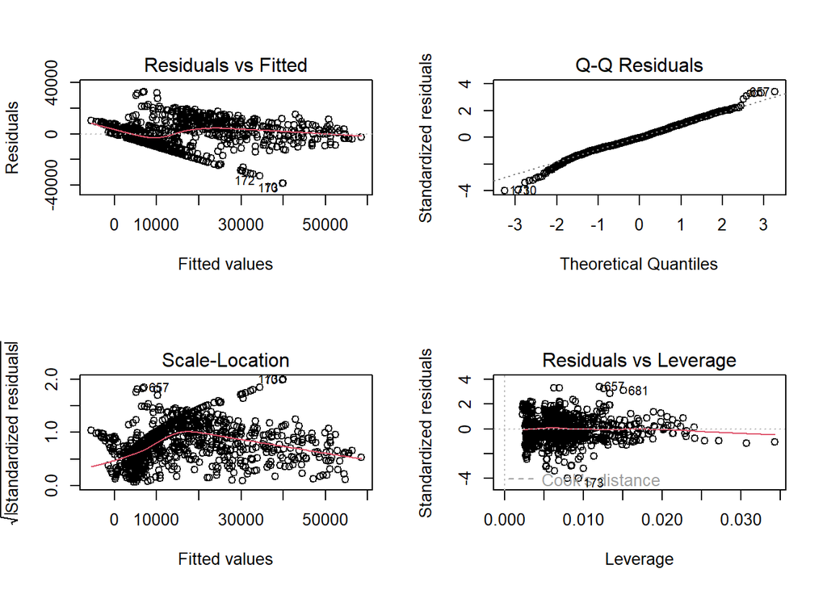

```r
# Visual Diagnostics:
par(mfrow = c(2, 2))
plot(initial_model_subset) # Checks Linearity and Homoscedasticity (Residuals vs Fitted), Normality (Q-Q plot)
```

```r
par(mfrow = c(1, 1))

# Statistical Tests:
dwtest(initial_model_subset)   # Independence of errors (Durbin-Watson test)
```

```
##
##  Durbin-Watson test
##
## data:  initial_model_subset
## DW = 1.2272, p-value < 2.2e-16
## alternative hypothesis: true autocorrelation is greater than 0
```

```r
bptest(initial_model_subset)   # Homoscedasticity (Breusch-Pagan test)
```

```
##
##  studentized Breusch-Pagan test
##
## data:  initial_model_subset
## BP = 95.235, df = 6, p-value < 2.2e-16
```

```r
shapiro.test(residuals(initial_model_subset)) # Normality of residuals (Shapiro-Wilk test)
```

```
##
##  Shapiro-Wilk normality test
##
## data:  residuals(initial_model_subset)
## W = 0.98963, p-value = 5.079e-06
```

```r
vif(initial_model_subset)      # Low Multicollinearity (Variance Inflation Factor)
```

```
##                       GVIF Df GVIF^(1/(2*Df))
## Living_Cost_Index 3.638559  1        1.907501
## Insurance_USD     3.071369  1        1.752532
## Rent_USD          3.639152  1        1.907656
## Level             7.430070  2        1.651004
## Duration_Years    7.674354  1        2.770262
```

## Analysis

The initial linear regression model reveals interesting relationships with tuition fees: while a higher living cost index surprisingly suggests a decrease in tuition (β=−769.25), increased insurance (β=13.56) and rent (β=33.54) costs are associated with higher tuition. Notably, Master’s programs show a statistically significant lower tuition compared to Bachelor’s (β=−3726.97,p<0.05), and although PhD programs also have a lower average tuition (β=−1432.03), this difference is not statistically significant, nor is the apparent negative relationship between program duration and tuition (β=−988.51). Overall, the model explains a substantial 65.6% of the variation in tuition fees (R^2 =0.6581, Adjusted R^2 =0.6559), and the statistically significant F-statistic (p<2.2e−16) confirms that the model as a whole has predictive power.

## Liner regression Model

To enhance the reliability and validity of our linear regression model, we must address the identified violations of its assumptions: for non-linearity and heteroscedasticity, potential remedies include transforming the target variable (Tuition_USD) or predictors, exploring polynomial terms for curvilinear relationships, or employing robust standard errors; given the cross-sectional nature of our data (n=907), the observed autocorrelation likely points to model misspecification, such as omitted variables or an incorrect functional form, rather than a time series issue; and while Ordinary Least Squares (OLS) is generally robust to moderate non-normality, the observed deviations could impact hypothesis testing, suggesting that the transformations considered for linearity and homoscedasticity might also prove beneficial in improving the normality of the residuals.

```r
# Filter out rows where Tuition_USD is 0
filtered_data <- International_Education_Costs %>%
  filter(Tuition_USD > 0)

# Convert 'Level' to a factor
filtered_data$Level <- as.factor(filtered_data$Level)

# Build Linear Regression Model with Log-Transformed Target
target_variable <- "Tuition_USD"
predictors_of_interest <- c("Living_Cost_Index", "Insurance_USD", "Rent_USD", "Level", "Duration_Years")
formula_str_log <- paste("log(", target_variable, ") ~", paste(predictors_of_interest, collapse = " + "))
model_log_transformed <- lm(formula_str_log, data = filtered_data)
summary(model_log_transformed)
```

```
##
## Call:
## lm(formula = formula_str_log, data = filtered_data)
##
## Residuals:
##     Min      1Q  Median      3Q     Max
## -3.4969 -0.4867  0.1398  0.6547  1.9081
##
## Coefficients:
##                     Estimate Std. Error t value Pr(>|t|)
## (Intercept)        9.7818628  0.4094466  23.890  < 2e-16 ***
## Living_Cost_Index -0.0391575  0.0043928  -8.914  < 2e-16 ***
## Insurance_USD      0.0004934  0.0001751   2.818  0.00496 **
## Rent_USD           0.0020502  0.0001195  17.154  < 2e-16 ***
## LevelMaster       -0.3280651  0.1569293  -2.091  0.03689 *
## LevelPhD          -0.1656296  0.1120060  -1.479  0.13960
## Duration_Years    -0.0679288  0.0937066  -0.725  0.46872
## ---
## Signif. codes:  0 '***' 0.001 '**' 0.01 '*' 0.05 '.' 0.1 ' ' 1
##
## Residual standard error: 0.9296 on 797 degrees of freedom
## Multiple R-squared:  0.4477, Adjusted R-squared:  0.4436
## F-statistic: 107.7 on 6 and 797 DF,  p-value: < 2.2e-16
```

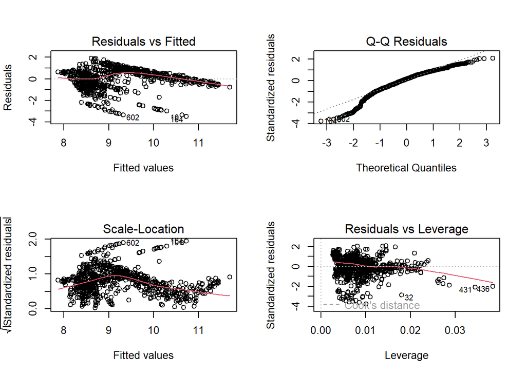

```r
# Sanity Checks on Transformed Model
par(mfrow = c(2, 2))
plot(model_log_transformed)
```

```r
par(mfrow = c(1, 1))

dwtest(model_log_transformed)
```

```
##
##  Durbin-Watson test
##
## data:  model_log_transformed
## DW = 1.1123, p-value < 2.2e-16
## alternative hypothesis: true autocorrelation is greater than 0
```

```r
bptest(model_log_transformed)
```

```
##
##  studentized Breusch-Pagan test
##
## data:  model_log_transformed
## BP = 64.99, df = 6, p-value = 4.333e-12
```

```r
shapiro.test(residuals(model_log_transformed))
```

```
##
##  Shapiro-Wilk normality test
##
## data:  residuals(model_log_transformed)
## W = 0.93906, p-value < 2.2e-16
```

```r
vif(model_log_transformed)
```

```
##                       GVIF Df GVIF^(1/(2*Df))
## Living_Cost_Index 3.736832  1        1.933089
## Insurance_USD     3.162431  1        1.778323
## Rent_USD          3.795890  1        1.948304
## Level             7.167776  2        1.636237
## Duration_Years    7.414414  1        2.722942
```

## Analysis

Following a log transformation of the target variable (Tuition_USD), the coefficients now represent the change in the logarithm of tuition: a one-unit increase in the Living Cost Index is associated with an approximate -3.8% change, while a one USD increase in insurance and rent corresponds to roughly 0.05% and 0.21% increases in tuition, respectively; Master’s programs still exhibit a statistically significant lower tuition of approximately -28% compared to Bachelor’s, whereas the non-significant lower tuition for PhD programs is about -15%, and each additional year of program duration is associated with an approximate -6.6% change in tuition, also not statistically significant; although the R-squared has decreased to 0.4477 (Adjusted R-squared = 0.4436), indicating that this model explains less variance in the log of tuition, the overall model remains statistically significant (p < 2.2e-16), and the suitability of this transformation hinges on whether it better addresses the previously identified assumption violations.

The sanity checks on the log-transformed model reveal mixed results: the “Residuals vs Fitted” plot shows a possible improvement in linearity with a less pronounced curve, but heteroscedasticity persists as suggested by the “Scale-Location” plot and the increasing spread of residuals; concerningly, the “Q-Q Residuals” plot and a highly significant Shapiro-Wilk test (p<2.2e−16) indicate that the log transformation has not improved the non-normality of the residuals, and similarly, the Durbin-Watson statistic of 1.1123 with a very small p-value (<2.2e−16) confirms that significant positive autocorrelation remains unresolved; on a positive note, multicollinearity continues to appear low based on the VIF values.

## Bootstrap

```r
library(glmnet)
x <- model.matrix(log(Tuition_USD) ~ Living_Cost_Index + Insurance_USD + Rent_USD + Level + Duration_Years, data = filtered_data)[, -1]
y <- log(filtered_data$Tuition_USD)

lasso_model <- glmnet(x, y, alpha = 1)
cv_lasso <- cv.glmnet(x, y, alpha = 1, nfolds = 10)
best_lambda_lasso <- cv_lasso$lambda.min
lasso_model_best <- glmnet(x, y, alpha = 1, lambda = best_lambda_lasso)

library(boot)
boot_lasso_coef <- function(data, indices) {
  d <- data[indices, ] # Resample the data

  d$Level <- as.factor(d$Level)

  x_boot <- model.matrix(log.Tuition_USD ~ Living_Cost_Index + Insurance_USD + Rent_USD + Level + Duration_Years, data = d)[, -1]
  y_boot <- d$log.Tuition_USD
  model <- glmnet(x_boot, y_boot, alpha = 1, lambda = best_lambda_lasso, lambda.min.ratio = 1e-5) # Refit Lasso
  return(as.vector(coef(model)))
}

boot_data <- data.frame(log(filtered_data$Tuition_USD), filtered_data[, c("Living_Cost_Index", "Insurance_USD", "Rent_USD", "Level", "Duration_Years")])
names(boot_data)[1] <- "log.Tuition_USD"

boot_results <- boot(data = boot_data, statistic = boot_lasso_coef, R = 1000)

print(boot_results)
```

```
##
## ORDINARY NONPARAMETRIC BOOTSTRAP
##
##
## Call:
## boot(data = boot_data, statistic = boot_lasso_coef, R = 1000)
##
##
## Bootstrap Statistics :
##         original        bias     std. error
## t1*  9.401704747  3.441355e-02 3.199181e-01
## t2* -0.035351199  1.218172e-04 5.133966e-03
## t3*  0.000406175  5.882500e-06 1.206182e-04
## t4*  0.001995918 -5.310504e-06 9.930503e-05
## t5* -0.208819651 -1.947224e-02 1.169538e-01
## t6* -0.173961879  4.296544e-03 9.102214e-02
## t7*  0.000000000 -1.118835e-02 5.350364e-02
```

```r
summary(boot_results)
```

```
##
## Number of bootstrap replications R = 1000
##      original    bootBias     bootSE     bootMed
## 1  9.40170475  3.4414e-02 3.1992e-01  9.42970783
## 2 -0.03535120  1.2182e-04 5.1340e-03 -0.03516137
## 3  0.00040618  5.8825e-06 1.2062e-04  0.00041205
## 4  0.00199592 -5.3105e-06 9.9305e-05  0.00198968
## 5 -0.20881965 -1.9472e-02 1.1695e-01 -0.22211321
## 6 -0.17396188  4.2965e-03 9.1022e-02 -0.17043159
## 7  0.00000000 -1.1188e-02 5.3504e-02  0.00000000
```

```r
boot_ci <- confint(boot_results, type = "perc")
print(boot_ci)
```

```
## Bootstrap percent confidence intervals
##
##          2.5 %        97.5 %
## 1  8.789726966 10.1239824239
## 2 -0.044803690 -0.0250268522
## 3  0.000182318  0.0006475189
## 4  0.001789182  0.0021848871
## 5 -0.491820128  0.0000000000
## 6 -0.350698878  0.0000000000
## 7 -0.139872302  0.0952117424
```

## Analysis

While the log transformation might have slightly improved linearity and homoscedasticity, we still have significant violations of: Homoscedasticity , Normality , Independence of Errors (Autocorrelation)

Considering the ongoing violations of model assumptions, we should explore additional strategies: to address heteroscedasticity, Weighted Least Squares (WLS) could be implemented if we can effectively model the variance of the residuals, and further transformations of the predictor variables might also prove beneficial; regarding the persistent autocorrelation in our cross-sectional data (n > 700 after filtering), this likely indicates model misspecification, prompting us to reconsider potential omitted variables or explore alternative functional forms; finally, while the Central Limit Theorem offers some robustness to the non-normality of our coefficient estimates due to the large sample size, the reliability of our t-test p-values might be compromised, suggesting that employing robust standard errors could be a prudent step.

## Robust Standard Errors

```r
# Load libraries (already loaded)
library(sandwich)
library(lmtest)

target_variable <- "Tuition_USD"
predictors_of_interest <- c("Living_Cost_Index", "Insurance_USD", "Rent_USD", "Level", "Duration_Years")
formula_str_log <- paste("log(", target_variable, ") ~", paste(predictors_of_interest, collapse = " + "))
model_log_robust <- lm(formula_str_log, data = filtered_data)

# Calculate robust standard errors
robust_se <- vcovHC(model_log_robust, type = "HC3")

robust_summary <- coeftest(model_log_robust, vcov. = robust_se)
print(robust_summary)
```

```
##
## t test of coefficients:
##
##                      Estimate  Std. Error t value  Pr(>|t|)
## (Intercept)        9.78186275  0.44683976 21.8912 < 2.2e-16 ***
## Living_Cost_Index -0.03915750  0.00524141 -7.4708 2.097e-13 ***
## Insurance_USD      0.00049343  0.00012938  3.8139 0.0001473 ***
## Rent_USD           0.00205016  0.00009767 20.9906 < 2.2e-16 ***
## LevelMaster       -0.32806507  0.16991920 -1.9307 0.0538731 .
## LevelPhD          -0.16562956  0.10169722 -1.6287 0.1037815
## Duration_Years    -0.06792881  0.09284005 -0.7317 0.4645816
## ---
## Signif. codes:  0 '***' 0.001 '**' 0.01 '*' 0.05 '.' 0.1 ' ' 1
```

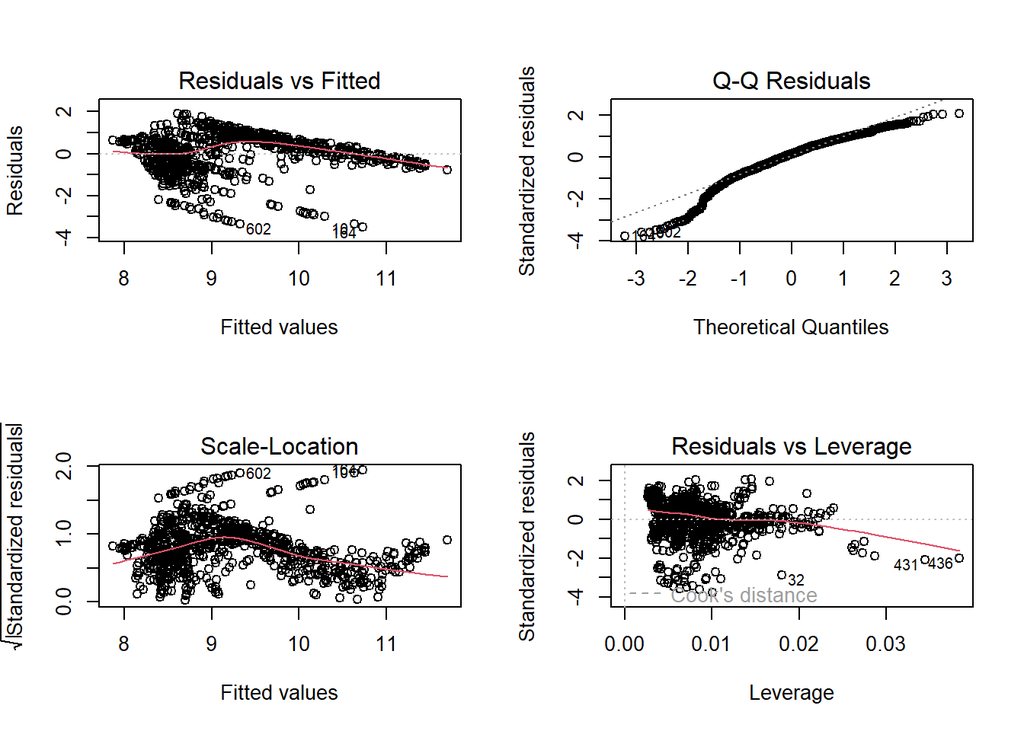

```r
par(mfrow = c(2, 2))
plot(model_log_robust)
```

```r
par(mfrow = c(1, 1))

dwtest(model_log_robust)
```

```
##
##  Durbin-Watson test
##
## data:  model_log_robust
## DW = 1.1123, p-value < 2.2e-16
## alternative hypothesis: true autocorrelation is greater than 0
```

```r
shapiro.test(residuals(model_log_robust))
```

```
##
##  Shapiro-Wilk normality test
##
## data:  residuals(model_log_robust)
## W = 0.93906, p-value < 2.2e-16
```

```r
vif(model_log_robust)
```

```
##                       GVIF Df GVIF^(1/(2*Df))
## Living_Cost_Index 3.736832  1        1.933089
## Insurance_USD     3.162431  1        1.778323
## Rent_USD          3.795890  1        1.948304
## Level             7.167776  2        1.636237
## Duration_Years    7.414414  1        2.722942
```

## Analysis

Despite the application of a log transformation and the use of robust standard errors, several assumption violations persist: the “Residuals vs Fitted” plot continues to suggest potential non-linearity, and the “Scale-Location” plot still indicates non-constant variance, which could affect the model’s efficiency even though robust standard errors improve inference; furthermore, the Shapiro-Wilk test still strongly rejects the normality of the residuals, and the Q-Q plot shows ongoing deviations; most concerningly, the Durbin-Watson test still signals significant autocorrelation, which in our cross-sectional data likely points to model misspecification, such as omitted variables or inadequately captured relationships; while the large sample size offers some protection against the impact of non-normality on coefficient estimates due to the Central Limit Theorem, and robust standard errors enhance the reliability of p-values in the presence of heteroscedasticity, the unresolved autocorrelation remains a key issue that needs further attention.

## Addtional comments.

In light of the remaining challenges, further steps we could take include: thoroughly investigating the counterintuitive negative relationship observed with the Living Cost Index, which might involve exploring more complex interactions or the influence of omitted variables; examining potential non-linear relationships by incorporating polynomial terms for the numeric predictors; diligently trying to identify and include other relevant predictor variables that are currently missing from the model; and considering alternative modeling techniques if the fundamental assumptions of linear regression continue to be significantly violated despite our efforts.

## Cross-Validation

Cross-validation, a crucial technique for estimating a model’s ability to generalize to new data, aids in model selection, hyperparameter tuning, and assessing prediction accuracy by addressing overfitting, facilitating comparisons among candidate models, and providing an estimate of out-of-sample error through procedures like splitting data into training and validation sets, training on the former, and evaluating on the latter using common metrics such as MSE, RMSE, MAE, and R^2 for regression, and accuracy, AUC, F1-score, and log-loss for classification.

```r
k <- 10
n <- nrow(filtered_data)

set.seed(123)
folds <- cut(sample(1:n), breaks = k, labels = FALSE)

cv_rmse_glm <- numeric(k)

# Perform k-fold cross-validation
for (i in 1:k) {
  # Create training and validation sets for the current fold
  validation_indices <- which(folds == i, arr.ind = TRUE)
  validation_data <- filtered_data[validation_indices, ]
  training_data <- filtered_data[-validation_indices, ]

    model_glm <- glm(log(Tuition_USD) ~ Living_Cost_Index + Insurance_USD + Rent_USD + Level + Duration_Years,
                   data = training_data, family = gaussian)

    predictions_glm <- predict(model_glm, newdata = validation_data, type = "response")

  rmse_glm <- sqrt(mean((predictions_glm - log(validation_data$Tuition_USD))^2))

  cv_rmse_glm[i] <- rmse_glm
}

cat("Cross-Validation RMSE (using glm) values for each fold:\n", cv_rmse_glm, "\n")
```

```
## Cross-Validation RMSE (using glm) values for each fold:
##  0.9694065 0.9426386 1.022845 1.024126 0.8407753 0.8790322 0.9885959 1.006262 0.7720276 0.8413466
```

```r
cat("Mean CV RMSE (using glm):", mean(cv_rmse_glm), "\n")
```

```
## Mean CV RMSE (using glm): 0.9287056
```

```r
# Build the full model
full_model <- lm(log(Tuition_USD) ~ Living_Cost_Index + Insurance_USD + Rent_USD + Level + Duration_Years,
                 data = filtered_data)

# based on AIC (both forward and backward steps)
stepwise_model <- step(full_model, direction = "both", trace = FALSE)

summary(stepwise_model)
```

```
##
## Call:
## lm(formula = log(Tuition_USD) ~ Living_Cost_Index + Insurance_USD +
##     Rent_USD + Level, data = filtered_data)
##
## Residuals:
##     Min      1Q  Median      3Q     Max
## -3.4672 -0.4858  0.1350  0.6527  1.9000
##
## Coefficients:
##                     Estimate Std. Error t value Pr(>|t|)
## (Intercept)        9.5180288  0.1875176  50.758  < 2e-16 ***
## Living_Cost_Index -0.0382820  0.0042222  -9.067  < 2e-16 ***
## Insurance_USD      0.0004573  0.0001678   2.725  0.00657 **
## Rent_USD           0.0020474  0.0001194  17.144  < 2e-16 ***
## LevelMaster       -0.2276617  0.0737565  -3.087  0.00209 **
## LevelPhD          -0.2069758  0.0963674  -2.148  0.03203 *
## ---
## Signif. codes:  0 '***' 0.001 '**' 0.01 '*' 0.05 '.' 0.1 ' ' 1
##
## Residual standard error: 0.9293 on 798 degrees of freedom
## Multiple R-squared:  0.4474, Adjusted R-squared:  0.4439
## F-statistic: 129.2 on 5 and 798 DF,  p-value: < 2.2e-16
```

## Analysis

The cross-validation results, displaying RMSE values ranging from about 0.77 to 1.02 across the 10 folds, illustrate the variability in the model’s prediction error depending on the specific data subsets used for training and evaluation; the mean CV RMSE of 0.9287 provides an overall estimate of the model’s performance on unseen data, and its close proximity to the residual standard error (approximately 0.93) from our robust log-transformed model summary suggests a good level of generalization with no apparent severe overfitting.

## Rationale for considering regularization.

We should consider regularization techniques primarily for three key reasons: to mitigate the potential instability in coefficient estimates arising from multicollinearity, even if our VIFs are mostly acceptable; to leverage the variable selection capabilities of Lasso (which can drive coefficients to zero) and the balanced approach of Elastic Net; and to potentially enhance the model’s ability to generalize to new data by penalizing complexity, especially if some degree of overfitting is present.

```r
library(glmnet)

# Convert factor variable 'Level' to dummy variables
x <- model.matrix(log(Tuition_USD) ~ Living_Cost_Index + Insurance_USD + Rent_USD + Level + Duration_Years, data = filtered_data)[, -1]
y <- log(filtered_data$Tuition_USD)

# Perform Ridge Regression (alpha = 0)
ridge_model <- glmnet(x, y, alpha = 0)
cv_ridge <- cv.glmnet(x, y, alpha = 0, nfolds = 10)
best_lambda_ridge <- cv_ridge$lambda.min
ridge_model_best <- glmnet(x, y, alpha = 0, lambda = best_lambda_ridge)
print("Best Ridge Model Coefficients:")
```

```
## [1] "Best Ridge Model Coefficients:"
```

```r
print(coef(ridge_model_best))
```

```
## 7 x 1 sparse Matrix of class "dgCMatrix"
##                             s0
## (Intercept)        8.976198660
## Living_Cost_Index -0.024673471
## Insurance_USD      0.000516209
## Rent_USD           0.001616917
## LevelMaster       -0.215124814
## LevelPhD          -0.185836921
## Duration_Years     0.014591671
```

```r
# Perform Lasso Regression (alpha = 1)
lasso_model <- glmnet(x, y, alpha = 1)
cv_lasso <- cv.glmnet(x, y, alpha = 1, nfolds = 10)
best_lambda_lasso <- cv_lasso$lambda.min
lasso_model_best <- glmnet(x, y, alpha = 1, lambda = best_lambda_lasso)
print("\nBest Lasso Model Coefficients:")
```

```
## [1] "\nBest Lasso Model Coefficients:"
```

```r
print(coef(lasso_model_best))
```

```
## 7 x 1 sparse Matrix of class "dgCMatrix"
##                              s0
## (Intercept)        9.4121756127
## Living_Cost_Index -0.0356143433
## Insurance_USD      0.0004106209
## Rent_USD           0.0020006009
## LevelMaster       -0.2104888081
## LevelPhD          -0.1768972266
## Duration_Years     .
```

```r
# Perform Elastic Net Regression (e.g., alpha = 0.5)
elastic_model <- glmnet(x, y, alpha = 0.5)
cv_elastic <- cv.glmnet(x, y, alpha = 0.5, nfolds = 10)
best_lambda_elastic <- cv_elastic$lambda.min
elastic_model_best <- glmnet(x, y, alpha = 0.5, lambda = best_lambda_elastic)
print("\nBest Elastic Net Model Coefficients:")
```

```
## [1] "\nBest Elastic Net Model Coefficients:"
```

```r
print(coef(elastic_model_best))
```

```
## 7 x 1 sparse Matrix of class "dgCMatrix"
##                              s0
## (Intercept)        9.3766238836
## Living_Cost_Index -0.0346191602
## Insurance_USD      0.0004223481
## Rent_USD           0.0019649600
## LevelMaster       -0.2132564490
## LevelPhD          -0.1773286419
## Duration_Years     .
```

## Analysis

Based on the best Lasso model identified through cross-validation for predicting the log of Tuition_USD, the significant predictors are: a negative coefficient for Living_Cost_Index (-0.0356) indicating approximately 3.5% lower tuition fees for each unit increase; a positive coefficient for Insurance_USD (0.00041) suggesting about a 0.04% increase in tuition per USD increase in cost; a positive coefficient for Rent_USD (0.00200) implying roughly a 0.20% increase in tuition per USD increase in monthly rent; a negative coefficient for LevelMaster (-0.2105) suggesting approximately 19% lower tuition for Master’s compared to Bachelor’s programs; and a negative coefficient for LevelPhD (-0.1769) indicating about 16% lower tuition for PhD compared to Bachelor’s programs; notably, the Lasso model excluded Duration_Years, suggesting it does not contribute a strong independent linear effect on Tuition_USD within this regularized model alongside the other predictors.

## Discussion and limitations

Our study aimed to understand what influences international education tuition costs, and our analysis revealed some interesting points. We found a surprising trend where higher living costs were linked to slightly lower tuition, while expectedly, higher insurance and rent costs were associated with higher tuition. The level of study also played a role, with Master’s and PhD programs generally being less expensive than Bachelor’s. Interestingly, the length of the program didn’t seem to have a direct impact on yearly tuition when other factors were considered. Overall, our model explained a good portion of the differences in tuition costs, suggesting these factors are important.

However, it’s important to consider some limitations of our study. We encountered some mathematical issues in our analysis, which could affect the accuracy of our results. We also didn’t have data on all the possible factors that could influence tuition, such as a school’s reputation or available financial aid, which might give us an incomplete picture. The unexpected link between living costs and tuition needs more investigation as it might be more complex than our model suggests. Additionally, our model’s accuracy is based on the data we had, and it might not perform the same with new information. Finally, our use of percentages to explain changes in tuition, while mathematically necessary, can sometimes be less straightforward to interpret. Therefore, while our findings offer valuable insights, future research should explore additional factors, investigate more complex relationships, and address the identified mathematical limitations to gain a more complete understanding of international education pricing

## Conclustion

Our analysis suggests that Living_Cost_Index, Insurance_USD, Rent_USD, and the Level of study are important factors influencing international education tuition costs. Interestingly, higher living costs appear to be associated with lower tuition, a relationship that warrants further investigation beyond the scope of this analysis. As expected, higher insurance and rent costs are associated with higher tuition fees. Master’s and PhD programs tend to have lower tuition than Bachelor’s programs. The duration of the program, as a linear predictor, did not appear to be a significant factor in the regularized model.

While we addressed some of the violations of linear regression assumptions through log transformation and robust standard errors, potential remaining non-linearity and autocorrelation should be acknowledged as limitations of this model. The use of regularization techniques like Lasso provided a more parsimonious model by performing variable selection.

In conclusion, this analysis provides a valuable approximation of the relationships between the selected factors and international tuition costs. However, future research could explore the counterintuitive relationship with the living cost index, investigate potential non-linear effects, consider additional relevant predictors, and delve into more advanced modeling techniques to further refine our understanding of this complex phenomenon. Remember that our statistical model is a simplification of reality, and further investigation could uncover more nuanced relationships.